# hw1

For the above part (Task 1 part a) 5 bookmakers are chosen, randomly. These bookmakers are ComeOn, Expekt, Tipico, SBOBET and Unibet, respectively. The 5 figures shows their probabilistic data over emprical data. Furthermore, x=y line is plotted on each figure as well. This line helps us determine whether a bookmaker is successful or not. As one can see except SBOBET all bookmakers plotted data are around this line, which may lead us to say, we expect SBOBET is the poorest one in guessing the bets. Moreover, the bins are selected with range of 0.05 units.

For the below part (Task 1 part b) Unibet is chosen. The plot shows Probabilistic mean data and Empirical mean data over years for a range of 0.4-0.5. Again the bins are selected with the range of 0.05 units. As you can see in the figure the probabilistic data changes from year to year slightly, whereas empirical data changes with more variation.

[output not shown]

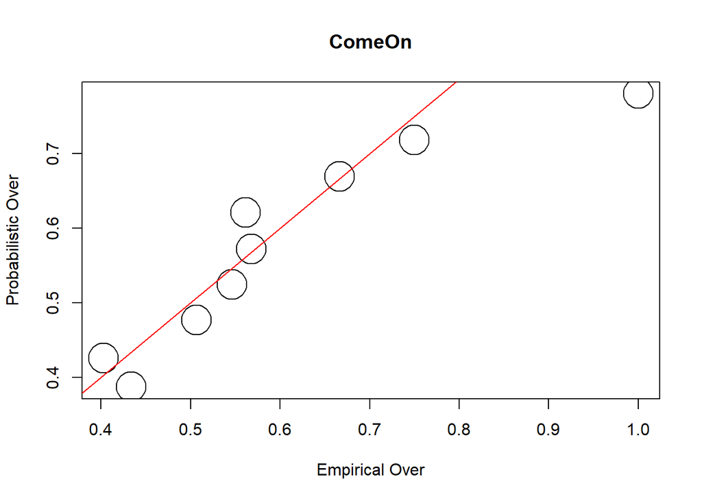

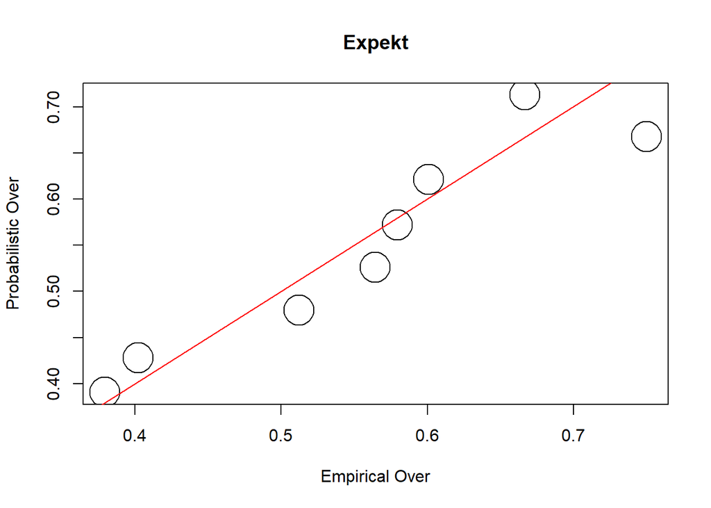

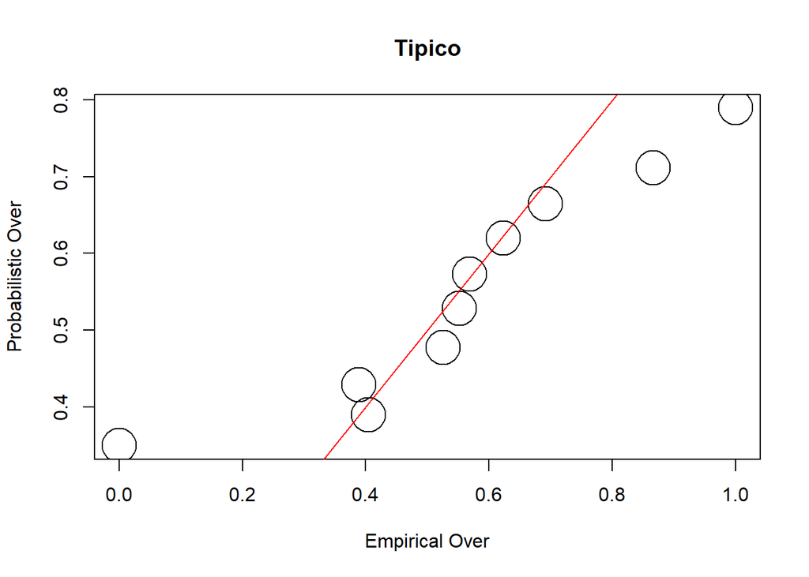

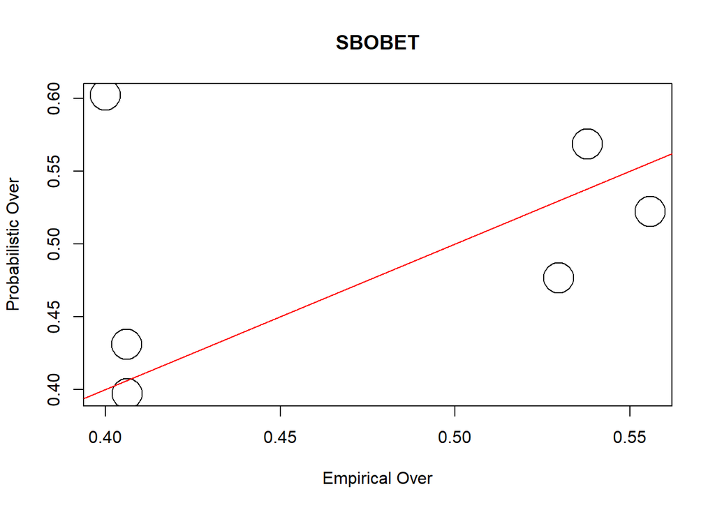

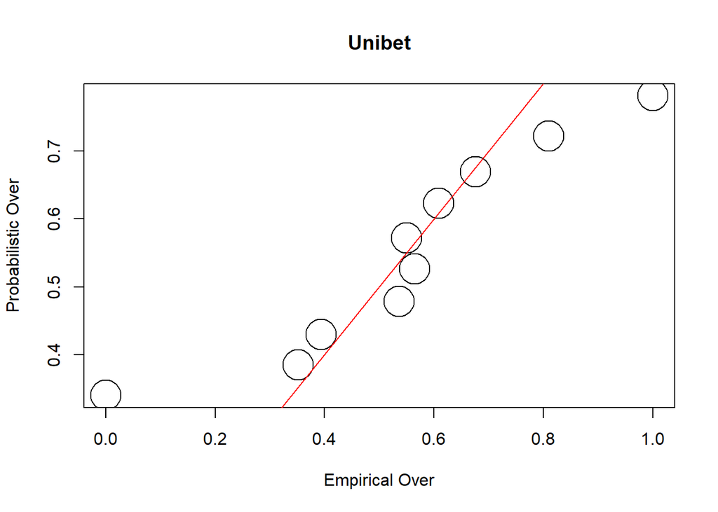

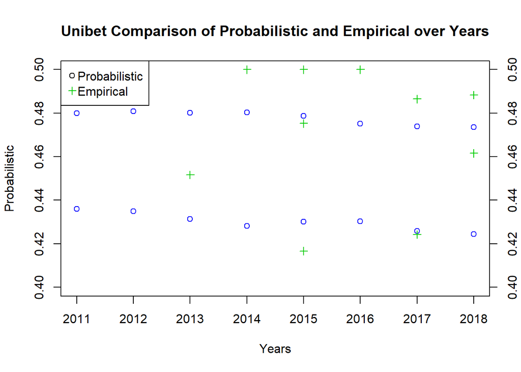